# Progress So Far

## Do Some Societies Not Care About The Spread Of COVID-19?

### The Battle Between Greed vs Wellbeing On The Individualistic - Collectivistic Cultural Orientation Continuum.

I have found data on countries [socioeconomic profiles](https://www.kaggle.com/nishanthsalian/socioeconomic-country-profiles), [COVID-19](https://www.kaggle.com/josephassaker/covid19-global-dataset?select=worldometer_coronavirus_summary_data.csv) and [cultural dimenstions](https://www.kaggle.com/tarukofusuki/hofstedes-6d-model-of-national-culture).

I have also done some data wrangling and merged parts of the data frames. This does need to be *cleaned up*. However, the code does **work**.

```r
library(tidyverse)
library(here)
library(countrycode)
library(data.table)
```

```r
library(plotly)
# Load in Covid data
covid <- read.csv(here("covid", "worldometer_coronavirus_summary_data.csv"))

# Load in cultural dimensions data
dim <- read.csv(here("dimensions", "six_dimenstions.csv"))

# Pars out cultural dimensions data
dim1 <- dim %>%
        separate(ctr.country.pdi.idv.mas.uai.ltowvs.ivr,
                 c("ctr", "country", "pdi", "idv", "mas", "uai", "lto", "ivr"),
                 sep = ";")

# Load socioeconomic data
ses <- read.csv(here("ses", "soci_econ_country_profiles.csv"))


# Selecting wanted Covid data

covid1 <- covid %>%
          select(country, total_cases_per_1m_population, total_deaths_per_1m_population)

# Selecting wanted cultural dimension data

dim2 <- dim1 %>%
        select(country, idv)

# Selecting wanted socioeconomic data

ses1 <- ses %>%
        select(country,GDP.per.capita..current.US..)

#Converting country ID to same country country codes

ses2 <- ses1
dim3 <-dim2
covid2 <- covid1

ses2$country <- countrycode(ses2$country, origin = "country.name", destination = "cowc")

dim3$country <- countrycode(dim3$country, origin = "country.name", destination = "cowc")

covid2$country <- countrycode(covid2$country, origin = "country.name", destination = "cowc")


#Adjoin dataframes with country codes

df_covid_dim <- inner_join(covid2, dim3, "country")

df_all <- inner_join(df_covid_dim, ses2, "country")

#Replacing names

df_covid_dim$country <- countrycode(df_covid_dim$country, origin = "cowc", destination = "country.name")

df_all$country <- countrycode(df_all$country, origin = "cowc", destination = "country.name")

# Deleting country missing data

df_covid_dim <- df_covid_dim %>%
                na.omit(country)

df_all <- df_all %>%
         na.omit(country)

#Removing rows with idv data as null

df_covid_dim <- df_covid_dim[!df_covid_dim$idv == "#NULL!", ]

df_all <- df_all[!df_all$idv == "#NULL!", ]

#Remove duplicate country coding

df_covid_dim <- df_covid_dim[!duplicated
                       (df_covid_dim[ , "country"]
                         ),]

df_all <- df_all[!duplicated
                        (df_all[ , "country"
                        ]),]


#Changing class

df_covid_dim$idv <- as.numeric(df_covid_dim$idv)
df_all$idv <- as.numeric(df_all$idv)
class(df_all$idv)
```

```
## [1] "numeric"
```

### Visualisation

I have also made a quick visualisation.

The individualism score measures the degree of interdependence with members of society. Low scores relate to a collectivist orientation and a high score individualist orientaiton. There are other variables within this dataset outlined [here](https://www.hofstede-insights.com/country-comparison/the-uk/)

Other measures I have parsed out is the countries GDP per capital ($) and COVID-19 deaths and cases per 1 million of the countries population.

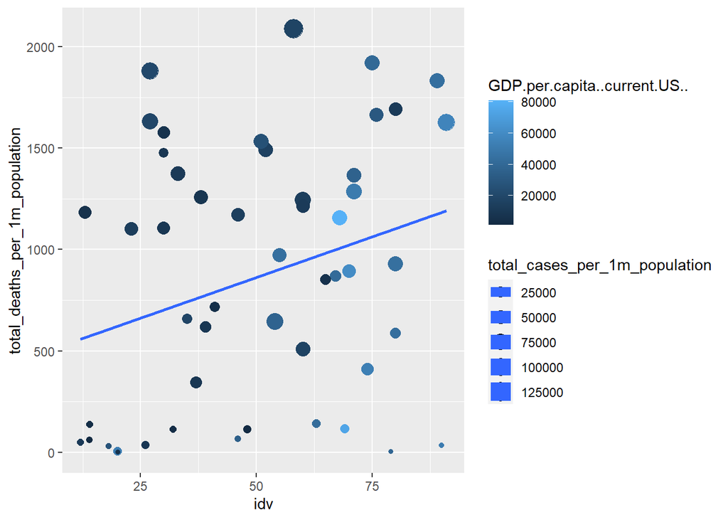

```r
plotx <- ggplot(df_all, aes(x = idv, y =             total_deaths_per_1m_population, size =total_cases_per_1m_population,
                          color = GDP.per.capita..current.US..)) + geom_point() + geom_smooth(method = 'lm', se = FALSE)
 print(plotx)
```

I am *unsure* whether to still use this data to visualise for my assignment. I may still explore the data I have. Additionally, I could use this data and triangulate it with other data such as adding a button that changes the outcome measure (i.e. not COVID-19). For example, see if there is any trends in the global happiness survey, countries GDP per capita and individualism etc.